### Introduction

A good education is often considered the safest avenue to ensure financial stability and career fulfillment. We will use the data from the General Social Survey to examine if there is a relationship between political leaning, and the attitude toward spending on educational improvement in the United States.

### About the source data

The original data comes from the General Social Survey (GSS), a sociological survey that collected data on demographic characteristics and attitudes of residents of the United States from 1972 to 2012. The information is collected through a questionnaire. Each case represents a person filling out the GSS questionnaire in a particular year. This is an observational study, more specifically a longitudinal study. The subjects of this study and the variables in the data were not influenced or controlled in any way.

The response (dependent) variable is the measure of attitude toward spending to improve the nation’s education system (neteduc). It is a categorical variable.

The explanatory (independent) variable is the self assessment of political views (poliviews). It is also a categorical variable.

A potential source of bias is that the survey respondents are self-assessing their political views. Self assessment can be erroneous, especially when trying to assess one’s political opinions. Another source of bias is the presence of NA values in some rows of both variables, these rows were removed but this implies we are working with a more limited set of data.

We can establish correlation between the variables but we should not infer causation since this is an observational study. We are not conducting an experiment. We cannot rule out the presence of a hidden variable.

### Data preparation and exploratory analysis

We begin by loading the source data set and subsetting it to just 3 variables (“year”,“polviews”,“nateduc”).

We will be working with a subset of the source data, from the year 2000 onward. This is ensure that we have data which reflects current opinion as much as possible.

Entries with NA values are also removed.

```r
load(url("http://bit.ly/dasi_gss_data")) #load the source dataset
gss2000 = gss[c("year","polviews","nateduc")] #keep only 3 variables: "year","polviews","nateduc"
gss2000 = subset(gss2000, gss2000$year >= 2000)
gss2000 = na.omit(gss2000)
```

We view the summary and structure of the subsetted data frame.

```r
summary(gss2000)
```

```
##       year                       polviews           nateduc
##  Min.   :2000   Extremely Liberal    : 278   Too Little :5018
##  1st Qu.:2002   Liberal              : 843   About Right:1487
##  Median :2006   Slightly Liberal     : 789   Too Much   : 386
##  Mean   :2006   Moderate             :2658
##  3rd Qu.:2010   Slightly Conservative:1001
##  Max.   :2012   Conservative         :1062
##                 Extrmly Conservative : 260
```

```r
str(gss2000)
```

```
## 'data.frame':    6891 obs. of  3 variables:
##  $ year    : int  2000 2000 2000 2000 2000 2000 2000 2000 2000 2000 ...
##  $ polviews: Factor w/ 7 levels "Extremely Liberal",..: 5 6 5 4 2 3 3 6 3 4 ...
##  $ nateduc : Factor w/ 3 levels "Too Little","About Right",..: 1 2 1 1 1 1 1 3 1 1 ...
##  - attr(*, "na.action")=Class 'omit'  Named int [1:12054] 2 5 6 10 12 13 15 16 17 19 ...
##   .. ..- attr(*, "names")= chr [1:12054] "38118" "38121" "38122" "38126" ...
```

Our response (dependent) variable has 3 levels.

```r
length(levels(gss2000$nateduc))
```

```
## [1] 3
```

```r
levels(gss2000$nateduc)
```

```
## [1] "Too Little"  "About Right" "Too Much"
```

Our explanatory (independent) variable has 7 levels.

```r
length(levels(gss2000$polviews))
```

```
## [1] 7
```

```r
levels(gss2000$polviews)
```

```
## [1] "Extremely Liberal"     "Liberal"               "Slightly Liberal"
## [4] "Moderate"              "Slightly Conservative" "Conservative"
## [7] "Extrmly Conservative"
```

The most sizable part of the survey respondents (~38%) identified their political views as moderate.

```r
prop.table(table(gss2000$polviews))
```

```
##
##     Extremely Liberal               Liberal      Slightly Liberal
##            0.04034248            0.12233348            0.11449717
##              Moderate Slightly Conservative          Conservative
##            0.38572051            0.14526194            0.15411406
##  Extrmly Conservative
##            0.03773037
```

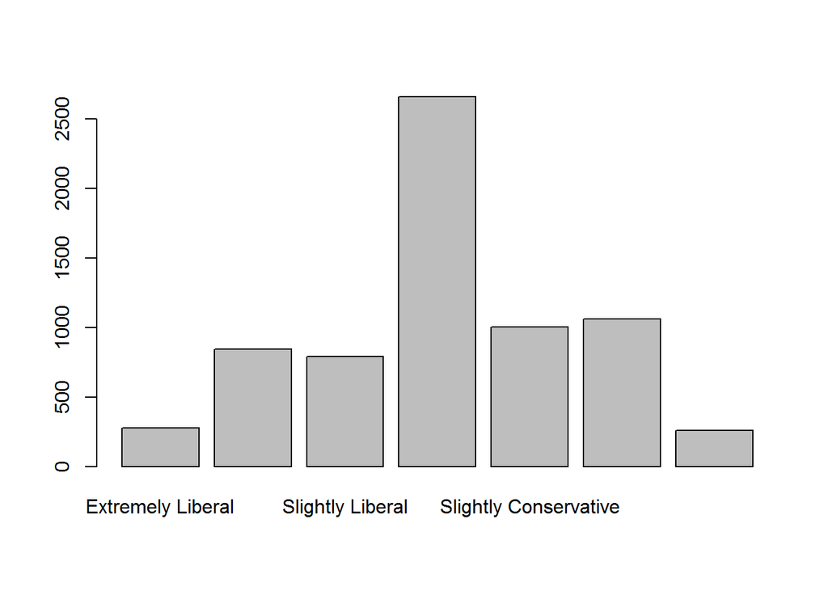

```r
barplot(table(gss2000$polviews))
```

We can see that a majority of the respondents (~73%) opined that there is too little money spent on improving the country’s educational system.

```r
prop.table(table(gss2000$nateduc))
```

```
##
##  Too Little About Right    Too Much
##  0.72819620  0.21578871  0.05601509
```

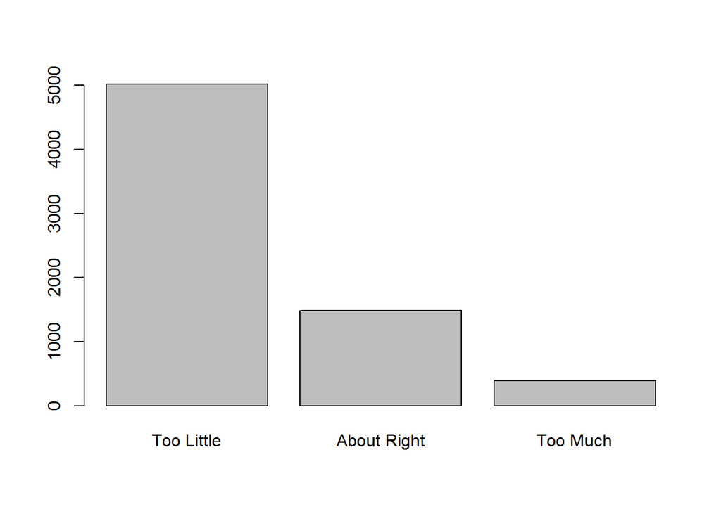

```r
barplot(table(gss2000$nateduc))
```

Using a mosaic plot, we can visualize the opinion spread across the two variables. Respondents who identified themselves on the liberal side of the political spectrum appear to favor the opinion that the US spends too little on improving education. Respondents who identified themselves as conservative appear more divided.

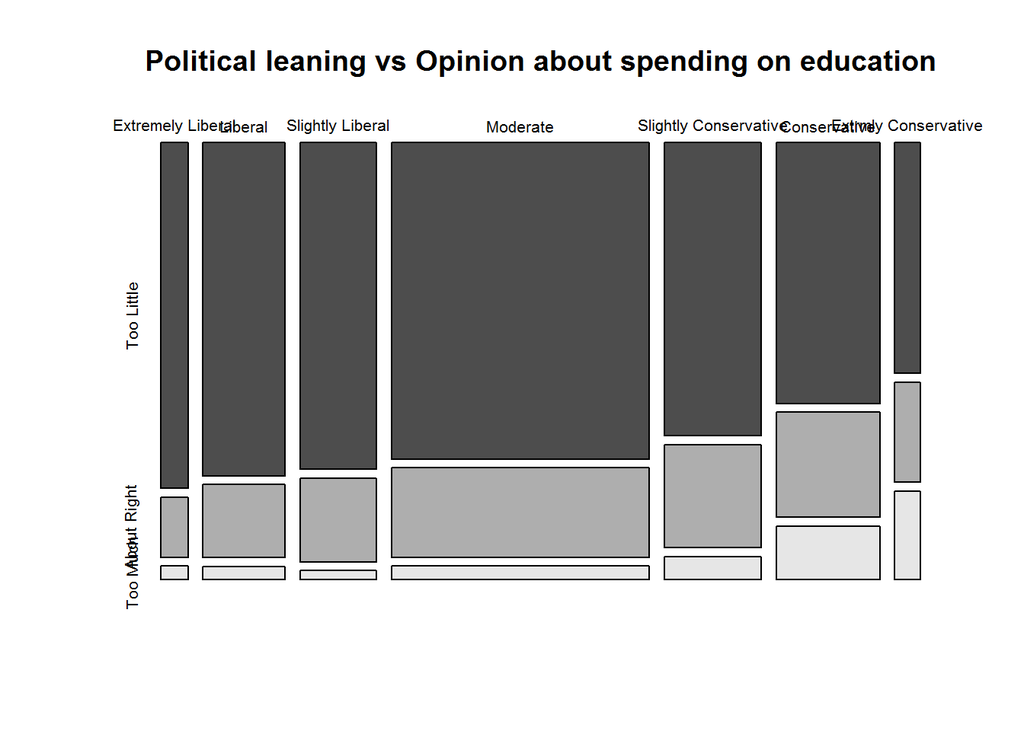

```r
mosaicplot(table(gss2000$polviews,gss2000$nateduc),color = T, main="Political leaning vs Opinion about spending on education")
```

### Inference

Since both variables are categorical and have more than 2 levels each, we will use the chi-square independence test.

The null hypothesis states that political leaning and the attitude toward spending on educational improvement are independent of each other. The attitude about spending on educational improvement does not vary based on where one falls on the political spectrum.

The alternative hypothesis states that political leaning and the attitude toward spending on educational improvement are dependent. The attitude about spending on educational improvement varies with where one falls on the political spectrum.

The conditions for the independence test are fulfilled:

1. The General Social Survey (GSS) used random sampling without replacement.
2. The sample size is less than 10% of the current population of the US.

```r
nrow(gss2000) < (318900000*0.10)
```

```
## [1] TRUE
```

3. Each case contributes to one cell at a time.
4. Each scenario has at least 5 expected cases.

```r
table(gss2000$polviews,gss2000$nateduc) >= 5
```

```
##
##                         Too Little About Right Too Much
##   Extremely Liberal           TRUE        TRUE     TRUE
##   Liberal                     TRUE        TRUE     TRUE
##   Slightly Liberal            TRUE        TRUE     TRUE
##   Moderate                    TRUE        TRUE     TRUE
##   Slightly Conservative       TRUE        TRUE     TRUE
##   Conservative                TRUE        TRUE     TRUE
##   Extrmly Conservative        TRUE        TRUE     TRUE
```

We can examine the contingency table (with sums displayed).

```r
addmargins(table(gss2000$polviews,gss2000$nateduc))
```

```
##
##                         Too Little About Right Too Much  Sum
##   Extremely Liberal            229          40        9  278
##   Liberal                      669         147       27  843
##   Slightly Liberal             614         158       17  789
##   Moderate                    2004         567       87 2658
##   Slightly Conservative        699         247       55 1001
##   Conservative                 660         266      136 1062
##   Extrmly Conservative         143          62       55  260
##   Sum                         5018        1487      386 6891
```

We run the chisq.test function.

```r
test = chisq.test(table(gss2000$polviews,gss2000$nateduc))
```

First we show the observed values.

```r
test$observed
```

```
##
##                         Too Little About Right Too Much
##   Extremely Liberal            229          40        9
##   Liberal                      669         147       27
##   Slightly Liberal             614         158       17
##   Moderate                    2004         567       87
##   Slightly Conservative        699         247       55
##   Conservative                 660         266      136
##   Extrmly Conservative         143          62       55
```

The expected value table was rounded off to the nearest second digit.

```r
round(test$expected, digits=2)
```

```
##
##                         Too Little About Right Too Much
##   Extremely Liberal         202.44       59.99    15.57
##   Liberal                   613.87      181.91    47.22
##   Slightly Liberal          574.55      170.26    44.20
##   Moderate                 1935.55      573.57   148.89
##   Slightly Conservative     728.92      216.00    56.07
##   Conservative              773.34      229.17    59.49
##   Extrmly Conservative      189.33       56.11    14.56
```

```r
test
```

```
##
##  Pearson's Chi-squared test
##
## data:  table(gss2000$polviews, gss2000$nateduc)
## X-squared = 332.64, df = 12, p-value < 2.2e-16
```

Since the p-value is very small we can reject the null hypothesis, which states that attitudes toward spending on educational improvement do not vary with political leaning. Instead we accept the alternative hypothesis that there is an association between the two variables.

### Summary

Overall, the General Social Survey (GSS) data has provided convincing evidence that political leaning and the opinion about spending on educational improvement are associated.

Nevertheless, we cannot surmise causality based on these results because this is an observational study, not an experiment. There could be confounding variables such as the respondent’s profession or age.

It would be interesting to have access to respondent data which provides more levels regarding the opinion on education spending by the government. We could get a clearer picture for the reasons why people agree or disagree about the alotted amount of money.

It would also be interesting to examine which other opinions about government spending in general follow a similar political leaning pattern.

### Citation

Smith, Tom W., Michael Hout, and Peter V. Marsden. General Social Survey, 1972-2012 [Cumulative File]. ICPSR34802-v1. Storrs, CT: Roper Center for Public Opinion Research, University of Connecticut /Ann Arbor, MI: Inter-university Consortium for Political and Social Research [distributors], 2013-09-11. doi:10.3886/ICPSR34802.v1

Persistent URL: http://doi.org/10.3886/ICPSR34802.v1

### Data sample

We output the first 50 rows of the data frame used for this report.

```r
print(head(gss2000,50))
```

```
##       year              polviews     nateduc
## 38117 2000 Slightly Conservative  Too Little
## 38119 2000          Conservative About Right
## 38120 2000 Slightly Conservative  Too Little
## 38123 2000              Moderate  Too Little
## 38124 2000               Liberal  Too Little
## 38125 2000      Slightly Liberal  Too Little
## 38127 2000      Slightly Liberal  Too Little
## 38130 2000          Conservative    Too Much
## 38134 2000      Slightly Liberal  Too Little
## 38138 2000              Moderate  Too Little
## 38139 2000      Slightly Liberal About Right
## 38140 2000          Conservative  Too Little
## 38142 2000              Moderate  Too Little
## 38144 2000              Moderate    Too Much
```

[output cut: 36 more lines]